# Spatio-temporal Modelling, Lab 3 2023-11-8

**This excercise will be discussed on 2023-11-15**

## 1 One-dimensional search with golden section

The function `optimize` (or, for that sake, `optimise`) optimizes a one-dimensional function. It uses a combination of golden section search and another approach. Let us try to fit the phase of a sin function.

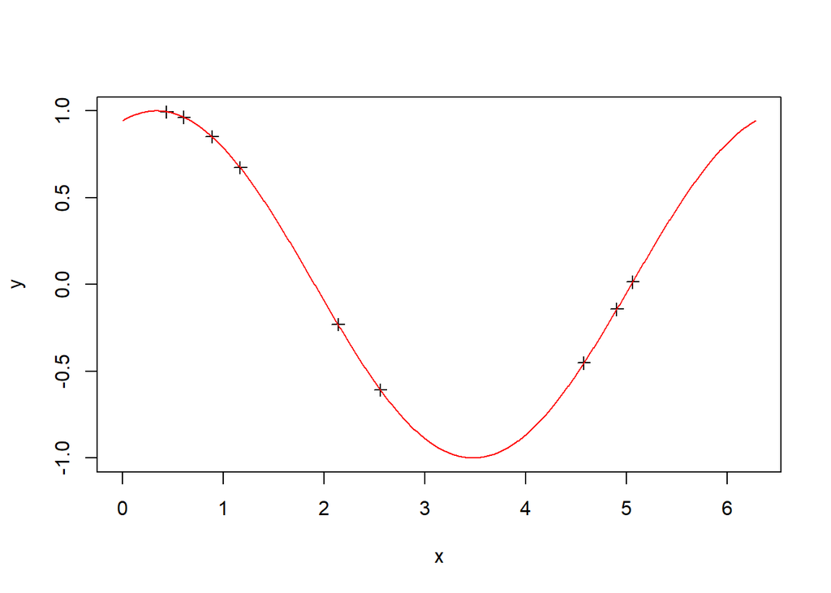

```r
phase = 1.23456789
x = runif(10) * 2 * pi
y = sin(x + phase)
plot(x, y, pch = 3, xlim = c(0, 2 * pi), ylim = c(-1, 1))
xx = seq(0, 2 * pi, length = 1000)
lines(xx, sin(xx + phase), col = "red")
```

```r
f = function(x, y, phase) sum((y - sin(x + phase))^2)
optimize(f, c(0, pi), x = x, y = y)
```

```
$minimum
[1] 1.234562

$objective
[1] 2.5171e-10
```

The optimization looks quite good, but approximates.

#### *Exercise 1*

**Exercise 1**

*How many parameters were fitted with the function call above?*

The function `optimize` has a parameter `tol` . Let us check whether more significant digits were fitted correctly, if we set the following value:

```r
out = optimize(f, c(0, pi), x = x, y = y, tol = 1e-08)
print(out$minimum, digits = 10)
```

```
[1] 1.234567897
```

#### *Exercise 2*

**Exercise 2**

*Is this fit better? Did optimize get the full 9 (or more) digits right?*

#### *Exercise 3 (i of iii)*

**Exercise 3**

*What is the other approach used? Search for the explanation of this method (English wikipedia), and briefly describe in your own words how it works.*

#### *Exercise 4 (ii of iii)*

**Exercise 4**

*Compare its properties to golden section search. What are the differences/similarities between both methods?*

#### *Exercise 5 (iii of iii)*

**Exercise 5**

*Explain why this method is used as well (hint: robustness/efficiency of optimization methods).*

## 2 Linear and non-linear least squares

As a preparation, go through the course slides; if you missed the lecture you may want to go through the Gauss-Newton algorithm, e.g. on [English wikipedia](https://en.wikipedia.org/wiki/Gauss-Newton_algorithm).

### 2.1 Linear least squares: Step-By-Step

First, we will try an example step by step using Rs. Consider the following data set:

| $x_1$ | $x_2$ | $y$ |
| --- | --- | --- |
| 0 | 0 | 5 |
| 0 | 1 | 7 |
| 0 | 2 | 6 |
| 1 | 0 | 5 |

and try to find the coefficients $b_0$, $b_1$ and $b_2$ of the linear regression equation

$$y = b_0 + b_1 x_1 + b_2 x_2 + e$$

(a trend surface in three dimensions), using the step-by-step example in the course slides.

**Hint**

Recall from the [lecture](https://edzer.github.io/mstp/op1.html#linear-least-squares-solution) that for finding the coefficients, we need to solve the normal equations $(X^TX)b = X^T y$. Try to define the matrices $X$ and the vector $y$, then you can use the `solve()` function for computing $b_0$, $b_1$, and $b_2$. Check the help of `solve()` to find out in what form you need to supply the equation system to the function in order to get the vector $b$ (corresponds to $x$ on the help page). When defining matrix $X$, keep in mind that the regression equation above includes a coefficient $b_0$, while we do not have any explicit values $x_0$ in our table. How can we include an intercept $b_0$? Think of $b_0$ as $b_0 \cdot 1$ !

#### *Exercise 6*

**Exercise 6**

*Report the values of the coeffients found and give the full equation; compute R (the sum of the squared residuals) ; report the steps used to compute R and the value found.*

### 2.2 Linear least squares: by lm

Fit the same model and check your results, found above:

```r
x1 = c(0, 0, 0, 1)
x2 = c(0, 1, 2, 0)
y = c(5, 7, 6, 5)
d = data.frame(x1 = x1, x2 = x2, y = y)
summary(lm(y ~ x1 + x2, d))
```

```
Call:
lm(formula = y ~ x1 + x2, data = d)

Residuals:
         1          2          3          4
-5.000e-01  1.000e+00 -5.000e-01  8.327e-17

Coefficients:
            Estimate Std. Error t value Pr(>|t|)
(Intercept)    5.500      1.118   4.919    0.128
x1            -0.500      1.658  -0.302    0.814
x2             0.500      0.866   0.577    0.667

Residual standard error: 1.225 on 1 degrees of freedom
Multiple R-squared:  0.4545,    Adjusted R-squared:  -0.6364
F-statistic: 0.4167 on 2 and 1 DF,  p-value: 0.7385
```

### 2.3 Non-linear least squares: using nls

Function nls uses a formula as its first argument, and a data frame as its second argument. In the [R introduction chapter 11](http://cran.r-project.org/doc/manuals/R-intro.html#Statistical-models-in-R), statistical models expressed as formula are explained. The general explanation here is on linear (and generalized linear) models.

Function nls uses, just like lm, a formula to define a model. It differs from lm formulas in that coefficients need to be named explicitly. In linear models, the coefficients are implicit, e.g. linear regression uses the function lm (linear model). Look at the following example.

```r
load("./data/meteo.RData")
lm(T.outside ~ hours, meteo)
```

```
Call:
lm(formula = T.outside ~ hours, data = meteo)

Coefficients:
(Intercept)        hours
    14.9933       0.0322
```

```r
summary(lm(T.outside ~ hours, meteo))
```

```
Call:
lm(formula = T.outside ~ hours, data = meteo)

Residuals:
     Min       1Q   Median       3Q      Max
-10.0929  -3.0422   0.1916   3.1414  10.1411

Coefficients:
             Estimate Std. Error t value Pr(>|t|)
(Intercept) 1.499e+01  1.042e-01  143.94   <2e-16 ***
hours       3.220e-02  9.616e-04   33.48   <2e-16 ***
---
Signif. codes:  0 '***' 0.001 '**' 0.01 '*' 0.05 '.' 0.1 ' ' 1

Residual standard error: 4.551 on 9888 degrees of freedom
Multiple R-squared:  0.1018,    Adjusted R-squared:  0.1017
F-statistic:  1121 on 1 and 9888 DF,  p-value: < 2.2e-16
```

This fits and summarized the linear regression model.

$$\textrm{T.outside} = \beta_0 + \beta_1 \textrm{hours} + e,$$

Here, $\beta_0$ (intercept) and $\beta_1$(slope) are implicit, and not named in the formula.

For non-linear models, we need to name coefficients explicitly, as they may in principle appear anywhere. In the example below, the now familiar sinus model is refitted using function nls, which uses Gauss-Newton optimization, and the coefficients are named a, b and c in the formula.

### 2.4 Initial conditions

Try to fit the following two models:

```r
nls(T.outside ~ a + b * sin(pi * (hours + c)/12), meteo, c(a = 0, b = 1, c = 0))
```

```
Nonlinear regression model
  model: T.outside ~ a + b * sin(pi * (hours + c)/12)
   data: meteo
      a       b       c
 18.190   4.905 -10.396
 residual sum-of-squares: 108956

Number of iterations to convergence: 8
Achieved convergence tolerance: 2.681e-07
```

```r
nls(T.outside ~ a + b * sin(pi * (hours + c)/12), meteo, c(a = 0, b = 1, c = 2))
```

```
Nonlinear regression model
  model: T.outside ~ a + b * sin(pi * (hours + c)/12)
   data: meteo
     a      b      c
18.190 -4.905  1.604
 residual sum-of-squares: 108956

Number of iterations to convergence: 5
Achieved convergence tolerance: 3.774e-08
```

The two fits provide different outcomes.

#### *Exercise 7*

**Exercise 7**

*What does the third argument to nls contain, and why does it change the outcome?*

#### *Exercise 8*

**Exercise 8**

*Does one of the models give a better fit?*

The following fit:

```r
nls(T.outside ~ a + b * sin(pi * (hours + c)/12), meteo, c(a = 0, b = 0, c = 0))
```

gives an error message.

#### *Exercise 9*

**Exercise 9**

*Explain why the error occured.*

#### *Exercise 10*

**Exercise 10**

*Compute the first three rows of the Jacobian matrix by hand.*

### 2.5 Iteration

The consecutive steps of the optimization are shown when a trace is requested.

```r
nls(T.outside ~ a + b * sin(pi * (hours + c)/12), meteo, c(a = 0, b = 1, c = 0), trace = TRUE)
```

```
3524904.    (5.60e+00): par = (0 1 0)
486295.2    (1.86e+00): par = (18.18955 -4.478377 -7.64)
275303.8    (1.24e+00): par = (18.18955 3.682868 -4.877138)
200236.0    (9.15e-01): par = (18.18955 0.6167406 -9.923752)
189247.8    (8.58e-01): par = (18.18955 4.86737 -13.66633)
123721.7    (3.68e-01): par = (18.18955 3.213819 -10.75871)
109253.1    (5.22e-02): par = (18.18955 4.882588 -10.20532)
108956.2    (1.31e-03): par = (18.18955 4.898656 -10.39634)
108956.1    (2.68e-07): par = (18.18955 4.904737 -10.39556)
```

```
Nonlinear regression model
  model: T.outside ~ a + b * sin(pi * (hours + c)/12)
   data: meteo
      a       b       c
 18.190   4.905 -10.396
 residual sum-of-squares: 108956

Number of iterations to convergence: 8
Achieved convergence tolerance: 2.681e-07
```

#### *Exercise 11*

**Exercise 11**

*What is the meaning of the four columns of additional output?*